# PROSPER LOAN DATA ANALYSIS)

## by (Nana H. Musa)

### TABLE OF CONTENT

> 1. INTRODUCTION
> 2. IMPORTING PACKAGES
> 3. DATA GATHERING
> 4. ACCESSING DATA
> 5. DATA CLEANING
> 6. UNIVARIATE EXPLORATION
> 7. BIVARIATE EXPLORATION
> 8. MULTIVARIATE EXPLORATION
> 9. CONCLUSION

## Introduction

This analysis is based on a set of data extracted from early 2000 in the banking system, it captures a wholistic loan disburement naratives with indept details of performing and non performing loans and other indices of granting loan like Employment status, occupation, term and so on. This data will also lead to answering questions below and more:

> What factors affect a loan’s outcome status?

> What affects the borrower’s APR or interest rate?

> Are there differences between loans depending on how large the original loan amount was?

## Importing Packages

```python
# import all packages and set plots to be embedded inline
import numpy as np
import pandas as pd
import matplotlib.pyplot as plt
import seaborn as sns

%matplotlib inline
```

## Data Gathering

```python
df = pd.read_csv("prosperLoanData.csv")
```

## Data Accessing

```python
df.head()
```

|  | ListingKey | ListingNumber | ListingCreationDate | CreditGrade | Term | LoanStatus | ClosedDate | BorrowerAPR | BorrowerRate | LenderYield | ... | LP_ServiceFees | LP_CollectionFees | LP_GrossPrincipalLoss | LP_NetPrincipalLoss | LP_NonPrincipalRecoverypayments | PercentFunded | Recommendations | InvestmentFromFriendsCount | InvestmentFromFriendsAmount | Investors |
| --- | --- | --- | --- | --- | --- | --- | --- | --- | --- | --- | --- | --- | --- | --- | --- | --- | --- | --- | --- | --- | --- |
| 0 | 1021339766868145413AB3B | 193129 | 2007-08-26 19:09:29.263000000 | C | 36 | Completed | 2009-08-14 00:00:00 | 0.16516 | 0.1580 | 0.1380 | ... | -133.18 | 0.0 | 0.0 | 0.0 | 0.0 | 1.0 | 0 | 0 | 0.0 | 258 |
| 1 | 10273602499503308B223C1 | 1209647 | 2014-02-27 08:28:07.900000000 | NaN | 36 | Current | NaN | 0.12016 | 0.0920 | 0.0820 | ... | 0.00 | 0.0 | 0.0 | 0.0 | 0.0 | 1.0 | 0 | 0 | 0.0 | 1 |
| 2 | 0EE9337825851032864889A | 81716 | 2007-01-05 15:00:47.090000000 | HR | 36 | Completed | 2009-12-17 00:00:00 | 0.28269 | 0.2750 | 0.2400 | ... | -24.20 | 0.0 | 0.0 | 0.0 | 0.0 | 1.0 | 0 | 0 | 0.0 | 41 |
| 3 | 0EF5356002482715299901A | 658116 | 2012-10-22 11:02:35.010000000 | NaN | 36 | Current | NaN | 0.12528 | 0.0974 | 0.0874 | ... | -108.01 | 0.0 | 0.0 | 0.0 | 0.0 | 1.0 | 0 | 0 | 0.0 | 158 |
| 4 | 0F023589499656230C5E3E2 | 909464 | 2013-09-14 18:38:39.097000000 | NaN | 36 | Current | NaN | 0.24614 | 0.2085 | 0.1985 | ... | -60.27 | 0.0 | 0.0 | 0.0 | 0.0 | 1.0 | 0 | 0 | 0.0 | 20 |

5 rows × 81 columns

```python
#showing total entries and columns
df.shape
```

```
(113937, 81)
```

## Data Cleaning

### Define 1

- Extracting required columns for analysis

### Code

```python
# Extracting our important analysis columns
df_loan = df.iloc[:,np.r_[1,2,3,4,5,7,8,19,29,32,35,46,49,63,67]]
```

### Test

```python
df_loan.head()
```

|  | ListingNumber | ListingCreationDate | CreditGrade | Term | LoanStatus | BorrowerAPR | BorrowerRate | EmploymentStatus | OpenCreditLines | OpenRevolvingMonthlyPayment | CurrentDelinquencies | DebtToIncomeRatio | StatedMonthlyIncome | LoanOriginalAmount | MonthlyLoanPayment |
| --- | --- | --- | --- | --- | --- | --- | --- | --- | --- | --- | --- | --- | --- | --- | --- |
| 0 | 193129 | 2007-08-26 19:09:29.263000000 | C | 36 | Completed | 0.16516 | 0.1580 | Self-employed | 4.0 | 24.0 | 2.0 | 0.17 | 3083.333333 | 9425 | 330.43 |
| 1 | 1209647 | 2014-02-27 08:28:07.900000000 | NaN | 36 | Current | 0.12016 | 0.0920 | Employed | 14.0 | 389.0 | 0.0 | 0.18 | 6125.000000 | 10000 | 318.93 |
| 2 | 81716 | 2007-01-05 15:00:47.090000000 | HR | 36 | Completed | 0.28269 | 0.2750 | Not available | NaN | 0.0 | 1.0 | 0.06 | 2083.333333 | 3001 | 123.32 |
| 3 | 658116 | 2012-10-22 11:02:35.010000000 | NaN | 36 | Current | 0.12528 | 0.0974 | Employed | 5.0 | 115.0 | 4.0 | 0.15 | 2875.000000 | 10000 | 321.45 |
| 4 | 909464 | 2013-09-14 18:38:39.097000000 | NaN | 36 | Current | 0.24614 | 0.2085 | Employed | 19.0 | 220.0 | 0.0 | 0.26 | 9583.333333 | 15000 | 563.97 |

```python
df_loan.columns
```

```
Index(['ListingNumber', 'ListingCreationDate', 'CreditGrade', 'Term',
       'LoanStatus', 'BorrowerAPR', 'BorrowerRate', 'EmploymentStatus',
       'OpenCreditLines', 'OpenRevolvingMonthlyPayment',
       'CurrentDelinquencies', 'DebtToIncomeRatio', 'StatedMonthlyIncome',
       'LoanOriginalAmount', 'MonthlyLoanPayment'],
      dtype='object')
```

```python
df_loan.describe()
```

|  | ListingNumber | Term | BorrowerAPR | BorrowerRate | OpenCreditLines | OpenRevolvingMonthlyPayment | CurrentDelinquencies | DebtToIncomeRatio | StatedMonthlyIncome | LoanOriginalAmount | MonthlyLoanPayment |
| --- | --- | --- | --- | --- | --- | --- | --- | --- | --- | --- | --- |
| count | 1.139370e+05 | 113937.000000 | 113912.000000 | 113937.000000 | 106333.000000 | 113937.000000 | 113240.000000 | 105383.000000 | 1.139370e+05 | 113937.00000 | 113937.000000 |
| mean | 6.278857e+05 | 40.830248 | 0.218828 | 0.192764 | 9.260164 | 398.292161 | 0.592052 | 0.275947 | 5.608026e+03 | 8337.01385 | 272.475783 |
| std | 3.280762e+05 | 10.436212 | 0.080364 | 0.074818 | 5.022644 | 447.159711 | 1.978707 | 0.551759 | 7.478497e+03 | 6245.80058 | 192.697812 |
| min | 4.000000e+00 | 12.000000 | 0.006530 | 0.000000 | 0.000000 | 0.000000 | 0.000000 | 0.000000 | 0.000000e+00 | 1000.00000 | 0.000000 |
| 25% | 4.009190e+05 | 36.000000 | 0.156290 | 0.134000 | 6.000000 | 114.000000 | 0.000000 | 0.140000 | 3.200333e+03 | 4000.00000 | 131.620000 |
| 50% | 6.005540e+05 | 36.000000 | 0.209760 | 0.184000 | 9.000000 | 271.000000 | 0.000000 | 0.220000 | 4.666667e+03 | 6500.00000 | 217.740000 |
| 75% | 8.926340e+05 | 36.000000 | 0.283810 | 0.250000 | 12.000000 | 525.000000 | 0.000000 | 0.320000 | 6.825000e+03 | 12000.00000 | 371.580000 |
| max | 1.255725e+06 | 60.000000 | 0.512290 | 0.497500 | 54.000000 | 14985.000000 | 83.000000 | 10.010000 | 1.750003e+06 | 35000.00000 | 2251.510000 |

```python
#new dataset structure

df_loan.shape
```

```
(113937, 15)
```

### What is the structure of your dataset?

> There are total of 113937 records and 15 features in our loan datasets.

### What is/are the main feature(s) of interest in your dataset?

> Our main features are Employement status, loan amount and repayment amount,Borrower apr and Borrower rate.

### What features in the dataset do you think will help support your investigation into your feature(s) of interest?

> The most important features is the Debt income ratio and StatedMonthlyIncome

## Univariate Exploration

### What is the distribution of interest rates borrowers?

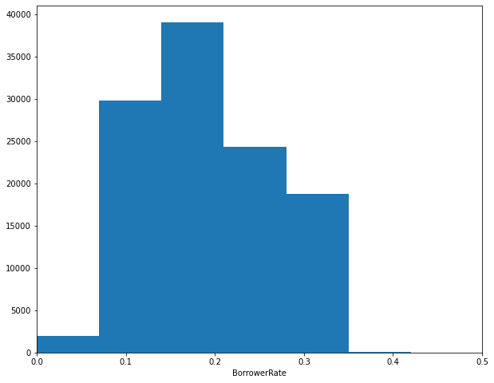

```python
def dist_plot(arg,size,xliml,xlimu):
    '''Plotting on a standard scaled plot'''
    bins = np.arange(0, df_loan[arg].max()+size, size)
    plt.figure(figsize=[10, 8])
    plt.hist(data = df_loan, x = arg, bins = bins)
    plt.xlabel(arg)
    plt.xlim(xliml,xlimu)
    plt.show()

dist_plot('BorrowerRate',0.07,0,0.5)
```

> From the hist chart above Borrowers rate have highest counts between 0.10 and 0.2 on loan amounts

### What is the distribution of loan original amount?

#### Logarithm transform

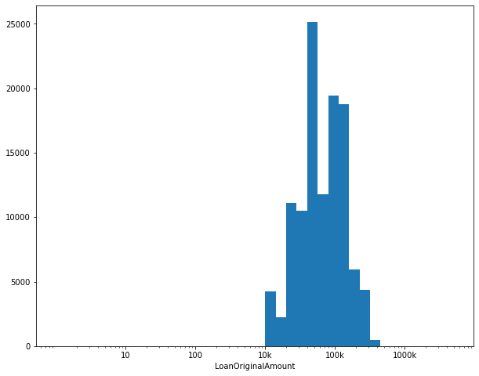

```python
plt.figure(figsize=[10,8])
bins_edges = 10 ** np.arange(0,5.684247 + 0.05,0.15)
plt.hist(data=df_loan, x='LoanOriginalAmount', bins=bins_edges );
plt.xscale('log')
ticks = [10,100,1000,10000,100000]
label = ['10','100','10k','100k','1000k']
plt.xlabel('LoanOriginalAmount')
plt.xticks(ticks,label);
```

### What is the distribution of monthly income of borrowers?

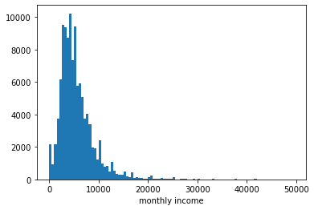

```python
bins_smi = np.arange(0, 50000, 500)
plt.hist(data = df_loan, x = 'StatedMonthlyIncome', bins=bins_smi);
plt.xlabel('monthly income')
```

### What is the distribution of employment status?

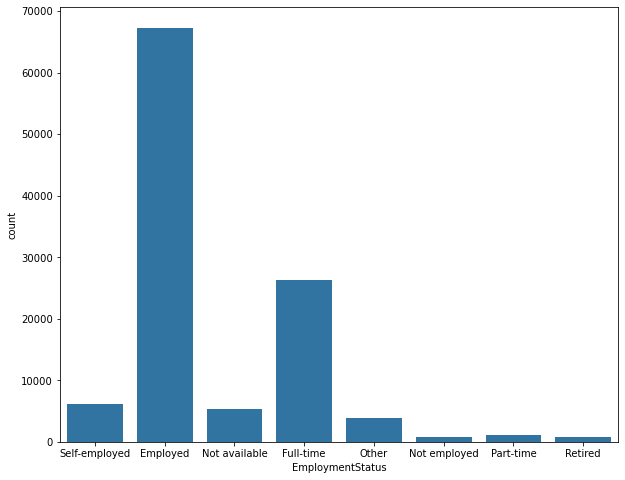

```python
plt.figure(figsize=[10,8])
color= sns.color_palette()[0]
sns.countplot(data=df_loan, x='EmploymentStatus', color=color);
```

### Distribution of borrower debt income ratio

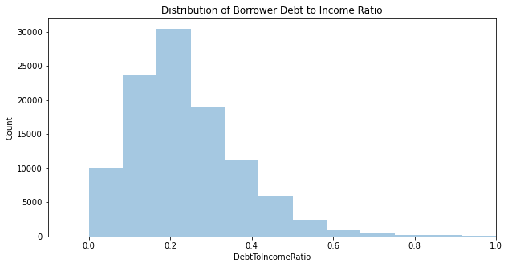

```python
# distribution of debt income ratio
plt.figure(figsize = [10,5])
sns.distplot(df_loan.DebtToIncomeRatio, bins = 120,kde = False)
plt.xlim(-.1, 1)
plt.xlabel('DebtToIncomeRatio')
plt.ylabel('Count')
plt.title('Distribution of Borrower Debt to Income Ratio');
```

The graph is slightly skewed to the right with a downward slope and the highest count of debt income ratio at 0.2, this implies that borrowers with high DSR ratio have lower access to loan because they considered high risk for investors

### Discuss the distribution(s) of your variable(s) of interest. Were there any unusual points? Did you need to perform any transformations?

> The distribution of Borrower debt to income is slightly skewed to the right with a downward slope and the highest count of debt income ratio at 0.2 and lowest count at 0.9. the data looked unimodal and does not need require transformation

### Of the features you investigated, were there any unusual distributions? Did you perform any operations on the data to tidy, adjust, or change the form of the data? If so, why did you do this?

> The distributions of stated monthly income is highly right skewed. Most stated monthly incomes are less than 30k, but some of them are incredibly high, like greater than 100k. Surprisingly, most of borrowers with greater than 100k monthly income only loan less than 5k dollars. So, the very large stated monthly income may be made up. Overall, Less than 0.3 percent borrowers have stated monthly income greater than 30k, these can be seemed as outlier for the following analysis, so it is better to remove borrower records with income greater than 30k.

## Bivariate Exploration

> In this section, investigate relationships between pairs of variables in your data. Make sure the variables that you cover here have been introduced in some fashion in the previous section (univariate exploration).

## Employment status and Borrow Rate

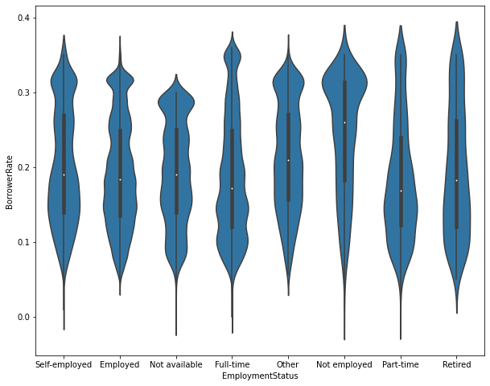

```python
plt.figure(figsize=[10,8])
color=sns.color_palette()[0]
sns.violinplot(data=df_loan,x='EmploymentStatus',y='BorrowerRate',color=color);
```

> The violin plot shows the different distribution of borrower rate accross employment status,the datasets are evenly spread across the median to max values with a long tail at minimum, signifying presence of outliers in all cases.

## Does monthly income determine monthly payment?

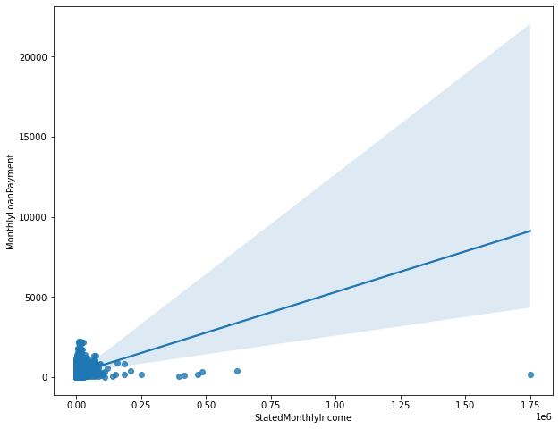

```python
plt.figure(figsize=[10,8])
sns.regplot(data=df_loan, x='StatedMonthlyIncome', y= 'MonthlyLoanPayment');
```

### Relationship between Borrwer APR vs Loan Amount

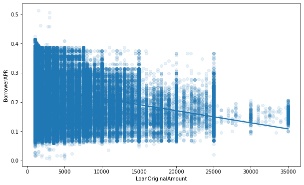

```python
plt.figure(figsize = [10, 6])
sns.regplot(data = df_loan, x = 'LoanOriginalAmount', y = 'BorrowerAPR', scatter_kws={'alpha':0.10});
```

> The regplot shows a negative correlation between borrrower APR and Loan amount whith a downward straightline slope

### Does Loan Original Amount have impact on term

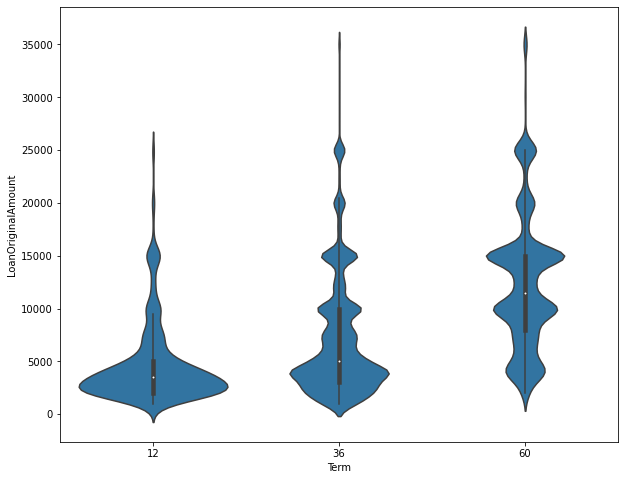

```python
plt.figure(figsize=[10,8])
color=sns.color_palette()[0]
sns.violinplot(data=df_loan,y='LoanOriginalAmount',x='Term',color=color);
```

> This particular violin plot has a right upward slopes, it signifies that at 12 months while at and 36 term is slightly more thin at the top signifying some outliers at max loan amount value

### Talk about some of the relationships you observed in this part of the investigation. How did the feature(s) of interest vary with other features in the dataset?

The regplot shows a negative correlation between borrrower APR and Loan amount whith a downward straightline slope

### Did you observe any interesting relationships between the other features (not the main feature(s) of interest)?

> The interesting part is that the violin plot has a right upward slopes, it signifies that at 12 months while at and 36 term is slightly more thin at the top signifying some outliers at max loan amount value.

## Multivariate Exploration

> Create plots of three or more variables to investigate your data even further. Make sure that your investigations are justified, and follow from your work in the previous sections.

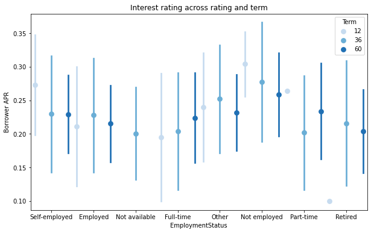

```python
fig = plt.figure(figsize = [10,6])
ax = sns.pointplot(data = df_loan, x= 'EmploymentStatus', y= 'BorrowerAPR', hue = 'Term',
           palette = 'Blues', linestyles = '', dodge = 0.8, ci='sd',bins=60 )
plt.title('Interest rating across rating and term')
plt.ylabel('Borrower APR')
ax.set_yticklabels([],minor = True);
```

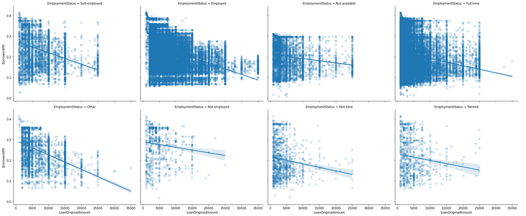

```python
# Employment effect on relationship of APR and loan amount
g=sns.FacetGrid(data=df_loan, aspect=1.2, height=5, col='EmploymentStatus', col_wrap=4)
g.map(sns.regplot, 'LoanOriginalAmount', 'BorrowerAPR', x_jitter=0.04, scatter_kws={'alpha':0.2});
g.add_legend();
```